# StatsProject

```python
# Importing all the required libraries
import pandas as pd
import numpy as np
import matplotlib.pyplot as plt
import seaborn as sns
from scipy import stats
```

```python
# Loading the dataset

df = pd.read_csv("E:/Data Analytics/Projects/Statistics/Dataset/US_Customer_Insights_Dataset.csv")

# Display the first five rows of the data
print(df.head())

# Getting the summary of the DataFrame
print(df.info())
```

```
  CustomerID              Name       State    Education      Gender  Age  \
0  CUST10319       Scott Perez     Florida  High School  Non-Binary   47
1  CUST10695   Jennifer Burton  Washington       Master        Male   72
2  CUST10297   Michelle Rogers     Arizona       Master      Female   40
3  CUST10103  Brooke Hendricks       Texas       Master        Male   27
4  CUST10219       Karen Johns       Texas  High School      Female   28

  Married  NumPets    JoinDate TransactionDate  MonthlySpend  \
0     Yes        1     9/19/21      09-02-2024       1281.74
1     Yes        0  04-05-2024      06-02-2024        429.46
2     Yes        2     7/24/24         2/28/25        510.34
3     Yes        0  08-12-2023         3/29/25        396.47
4     Yes        1  12-06-2021         7/24/22        139.68

   DaysSinceLastInteraction
0                       332
1                       424
2                       153
3                       124
4                      1103
<class 'pandas.core.frame.DataFrame'>
RangeIndex: 10675 entries, 0 to 10674
Data columns (total 12 columns):
 #   Column                    Non-Null Count  Dtype
---  ------                    --------------  -----
 0   CustomerID                10675 non-null  object
 1   Name                      10675 non-null  object
 2   State                     10675 non-null  object
 3   Education                 10675 non-null  object
 4   Gender                    10675 non-null  object
 5   Age                       10675 non-null  int64
 6   Married                   10675 non-null  object
 7   NumPets                   10675 non-null  int64
 8   JoinDate                  10675 non-null  object
 9   TransactionDate           10675 non-null  object
 10  MonthlySpend              10675 non-null  float64
 11  DaysSinceLastInteraction  10675 non-null  int64
dtypes: float64(1), int64(3), object(8)
memory usage: 1000.9+ KB
None
```

```python
# Describing the numerical columns
print(df[['Age', 'MonthlySpend', 'DaysSinceLastInteraction']].describe())

# Calculating the mode for categorical columns
print(df[['Gender', 'Education', 'Married']].mode())
```

```
                Age  MonthlySpend  DaysSinceLastInteraction
count  10675.000000  10675.000000              10675.000000
mean      49.474567    331.610315                538.469883
std       18.221365    225.799253                398.766747
min       18.000000      3.890000                  1.000000
25%       35.000000    165.495000                218.000000
50%       49.000000    282.110000                445.000000
75%       66.000000    443.255000                788.500000
max       80.000000   1740.420000               1791.000000
  Gender Education Married
0   Male    Master      No
```

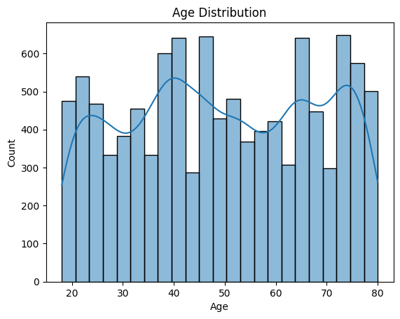

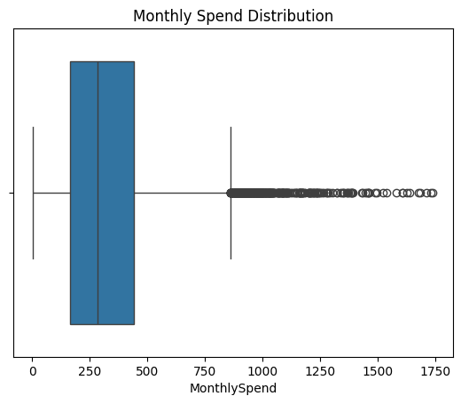

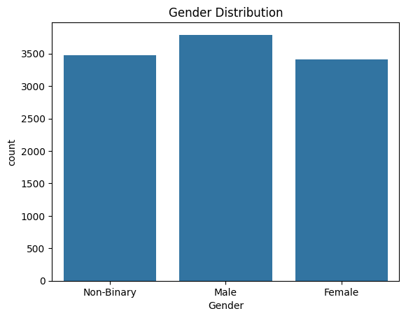

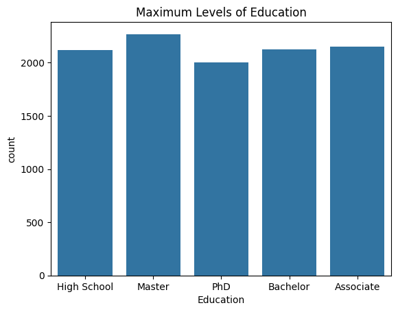

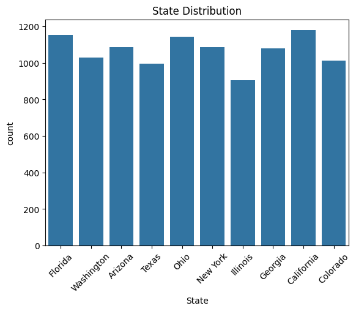

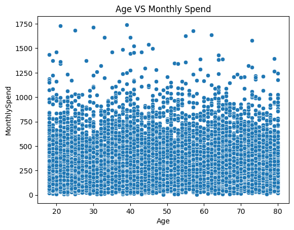

```python
# Creating Plots to visualize the data

# Histogram for age
sns.histplot(df['Age'], kde = True)
plt.title('Age Distribution')
plt.show()

# Boxplot for Monthly Spend
sns.boxplot(x = df['MonthlySpend'])
plt.title('Monthly Spend Distribution')
plt.show()

# Bar chart for Gender
sns.countplot(x = 'Gender', data = df)
plt.title('Gender Distribution')
plt.show()

# Bar Chart for Education
sns.countplot(x = 'Education', data = df)
plt.title('Maximum Levels of Education')
plt.show()

# Bar Chart for State
sns.countplot(x = 'State', data = df)
plt.title('State Distribution')
plt.xticks(rotation = 45)
plt.show()

# Scatter plot for Age vs Monthly Spend
sns.scatterplot(x = 'Age', y = 'MonthlySpend', data = df)
plt.title('Age VS Monthly Spend')
plt.show()
```

```python
# Correlation Matrix for Numeric Variables
num_columns = ['Age', 'NumPets', 'MonthlySpend', 'DaysSinceLastInteraction']
corr_matrix = df[num_columns].corr()
print(corr_matrix)

# Crosstab for Gender VS Married
cross_table = pd.crosstab(df['Gender'], df['Married'])
print('\n',cross_table)

#Average monthly spend by State, Education and Gender
avg_monthly_spend = df.groupby(['State','Education', 'Gender'])['MonthlySpend'].mean()
print('\n',avg_monthly_spend)
```

```
                               Age   NumPets  MonthlySpend  \
Age                       1.000000 -0.023035     -0.012323
NumPets                  -0.023035  1.000000      0.020647
MonthlySpend             -0.012323  0.020647      1.000000
DaysSinceLastInteraction -0.003970 -0.055227      0.006081

                          DaysSinceLastInteraction
Age                                      -0.003970
NumPets                                  -0.055227
MonthlySpend                              0.006081
DaysSinceLastInteraction                  1.000000

 Married       No   Yes
Gender
Female      1797  1616
Male        1892  1899
Non-Binary  1894  1577

 State       Education  Gender
Arizona     Associate  Female        329.187368
                       Male          360.346500
                       Non-Binary    316.102045
            Bachelor   Female        330.911944
                       Male          344.251266
                                        ...
Washington  Master     Male          305.584615
                       Non-Binary    318.771333
            PhD        Female        368.058765
                       Male          333.002703
                       Non-Binary    351.268642
Name: MonthlySpend, Length: 150, dtype: float64
```

```python
# To check the spending patterns of Males and Females
male_spend = df[df['Gender'] == 'Male']['MonthlySpend']
female_spend = df[df['Gender'] == 'Female']['MonthlySpend']

#Performing t-test
t_stat, p_value = stats.ttest_ind(male_spend, female_spend)
print(f'T Statistic: {t_stat}, P-Value: {p_value}')

# Defining the significance level
alpha = 0.05

# Interpretating the results
if p_value < alpha:
    print("\nResult: Reject the null hypothesis. The average monthly spend between Males and Females is significantly different.")
else:
    print("\nResult: Fail to reject the null hypothesis. There is no significant difference in average monthly spend between Males and Females.")
```

```
T Statistic: 0.3391730320232445, P-Value: 0.7344892727022859

Result: Fail to reject the null hypothesis. There is no significant difference in average monthly spend between Males and Females.
```

Interpretation:

- T Statistic is approximately 0.3392 which is close to 0, which means the difference between the average spending of Males and Females are very small.
- With P-Value being 0.7345, we can say that the average spending pattern of Males and Females are about the same and the small difference we see are likely due to random chance.

```python
# Creating empty list to store spend for each education level
spend_by_edu = []

# To get the list of unique education levels
edu_levels = df['Education'].unique()

# Looping through each education level
for level in edu_levels:
    # Finding all the rows in the DataFrame where the 'Education' column matches the current 'level'
    monthly_spend_level = df[df['Education'] == level]['MonthlySpend']

    # Adding this new data to our list
    spend_by_edu.append(monthly_spend_level)

# Performing ANOVA test to check if the education level impact the monthly average spend
f_stat, p_value = stats.f_oneway(*spend_by_edu)

print(f"F Statistic: {f_stat}, P-Value: {p_value}")

# Defining the significance level
alpha = 0.05

# Interpretating the results
if p_value < alpha:
    print("\nResult: Reject the null hypothesis. There is a significant difference in the average monthly spend across different education levels.")
else:
    print("\nResult: Fail to reject the null hypothesis. There is no significant difference in average monthly spend across different education levels.")
```

```
F Statistic: 0.2288066867370917, P-Value: 0.922359467759936

Result: Fail to reject the null hypothesis. There is no significant difference in average monthly spend across different education levels.
```

Interpretation:

Conclusion: Every one spends the same across different education levels.

```python
# Calculating Pearson's Correlation and P-value between Age and Days Since Last Interaction
corr_coef, p_value = stats.pearsonr(df['Age'], df['DaysSinceLastInteraction'])

print(f"Pearson Correlation Coefficient: {corr_coef}, P-Value : {p_value}")

# Defining the significance level
alpha = 0.05

# Interpretating the results
if p_value < alpha:
    print("\nResult: Reject the null hypothesis. There is a significant correlation between Age and the days since the last interation of the customers.")
else:
    print("\nResult: Fail to reject the null hypothesis. There is no significant correlation between the Age and the days since the last interaction of the customers.")
```

```
Pearson Correlation Coefficient: -0.0039702301049550455, P-Value : 0.681690543730097

Result: Fail to reject the null hypothesis. There is no significant correlation between the Age and the days since the last interaction of the customers.
```

Pearson Correlation Coefficient: -0.0040

- This is extremely close to zero. This indicates that there is very weak or no relationship between the customer's age and the number of days since their last interaction.

P-Value: 0.6817

- This is high and well above 0.05 threshold thus we fail to reject the null hypothesis.
- It means that is no correlation between the cutomer's age and the number of days since their last interaction.

```python
# Creating an empty list to hold the spending data for each state
spend_by_state = []

# to get the list of unique states
states = df['State'].unique()

#Looping through each state
for state in states:
    state_spending = df[df['State'] == state]['MonthlySpend']

    #Adding this data to the List created
    spend_by_state.append(state_spending)


# Performing ANOVA test
f_stat, p_value = stats.f_oneway(*spend_by_state)
print(f"F Statistic: {f_stat}, P-Value: {p_value}")

# Defining the significance level
alpha = 0.05

# Interpretating the results
if p_value < alpha:
    print("\nResult: Reject the null hypothesis. There is a significant variation in state wise spending")
else:
    print("\nResult: Fail to reject the null hypothesis. There is no significant variation in state wise spending.")
```

```
F Statistic: 1.1178423640877182, P-Value: 0.34571886479238273

Result: Fail to reject the null hypothesis. There is no significant variation in state wise spending.
```

F Statictic: 1.1178

- The value is low, which suggests that the variation in monthly spending across different states are almost the same.

P-Value: 0.3457

- The P-Value is significnatly higher than the usual 0.05 threshold, so we fail to reject the null hypothesis.
- This means that there is no significant difference in the spending habits across the states.
- Any differences that we observe is likely due to random chance.